# 01 - ggplot2 intro

## Aesthetics

Once we have an empty plot, we can start adding layers to it. `ggplot2` requires a data frame. It can’t work with matrix or list or other data types.

Our X axis is `displ` and Y axis is `cty`. These are aethetics *mappings* for `ggplot2`. They are wrapped inside an `aes()` function.

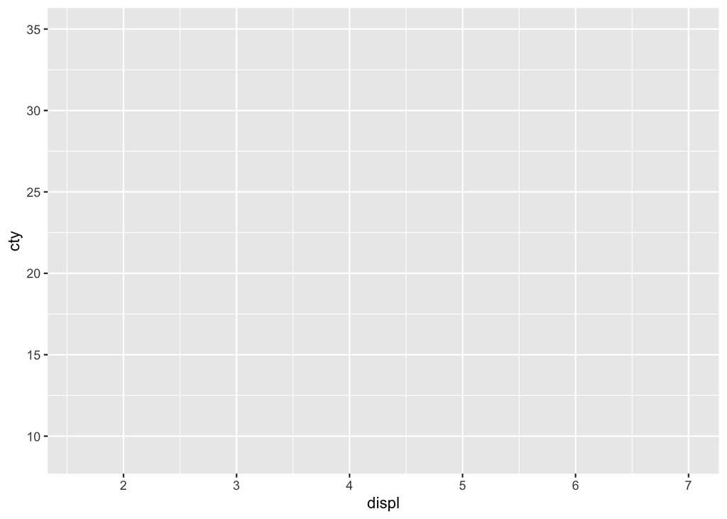

```r
ggplot(data = mpg,
       mapping = aes(x = displ, y = cty))
```

Now, we mapped X and Y axes to two variables in the data but no plot is visible. This is because we need to provide this instruction to `ggplot2` using `geom_*()` functions. These are geometric shapes for `ggplot2`.

As both `displ` and `cty` are numeric variables, it makes sense to create a scatterplot.

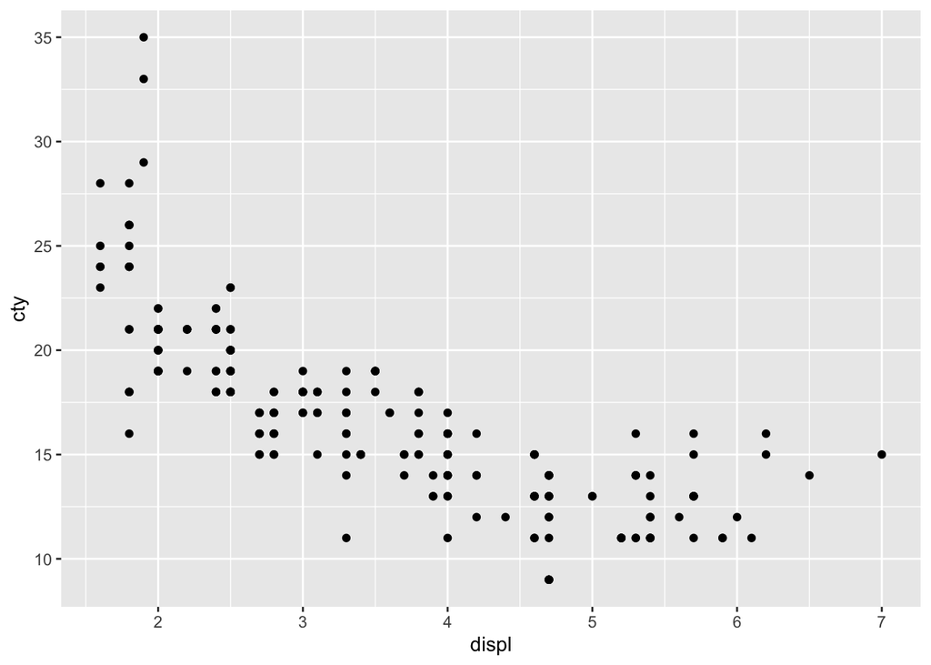

```r
ggplot(data = mpg,
       mapping = aes(x = displ, y = cty)) +
  geom_point() # this layer adds points to the plot
```

And just like that you created your first scatterplot!

As a data scientist, I am tempted to overlay a line on this scatterplot to summarize the relationship. We can acheive that by using `geom_smooth()`

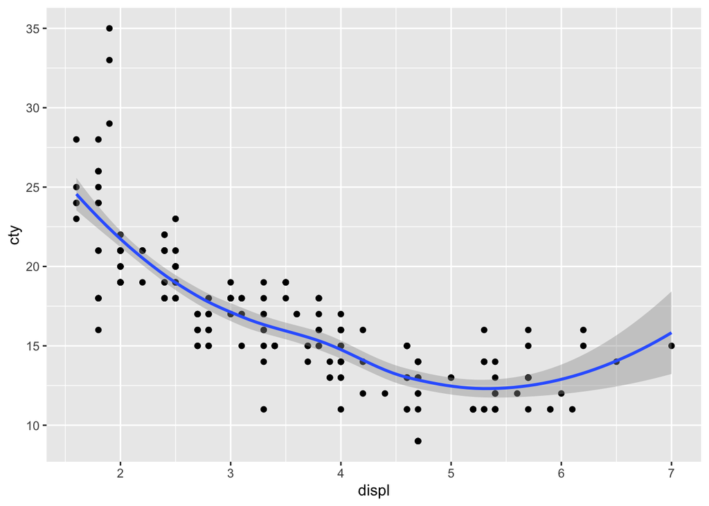

```r
ggplot(data = mpg,
       mapping = aes(x = displ, y = cty)) +
  geom_point() +
  geom_smooth()
```

By default, ggplot2 adds a line estimated using LOESS (Savitzky–Golay filter) (https://en.wikipedia.org/wiki/Local_regression)

We can easily change it to a linear regression by specifying `method` argument.

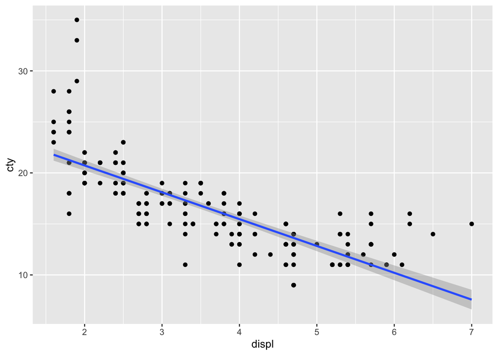

```r
ggplot(data = mpg,
       mapping = aes(x = displ, y = cty)) +
  geom_point() +
  geom_smooth(method = "lm")
```

## Boxplot

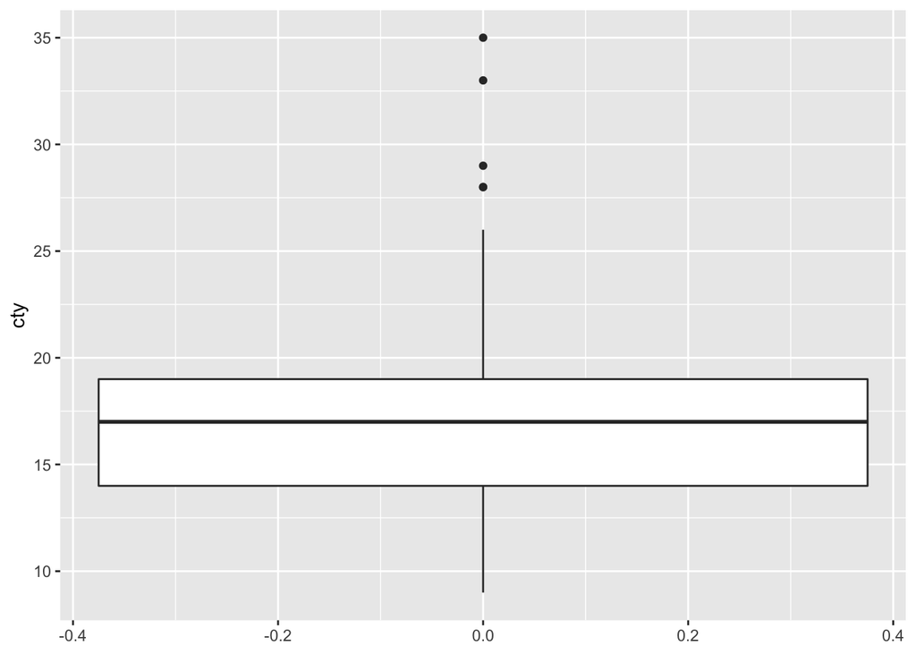

```r
ggplot(data = mpg,
       mapping = aes(y = cty)) +
  geom_boxplot()
```

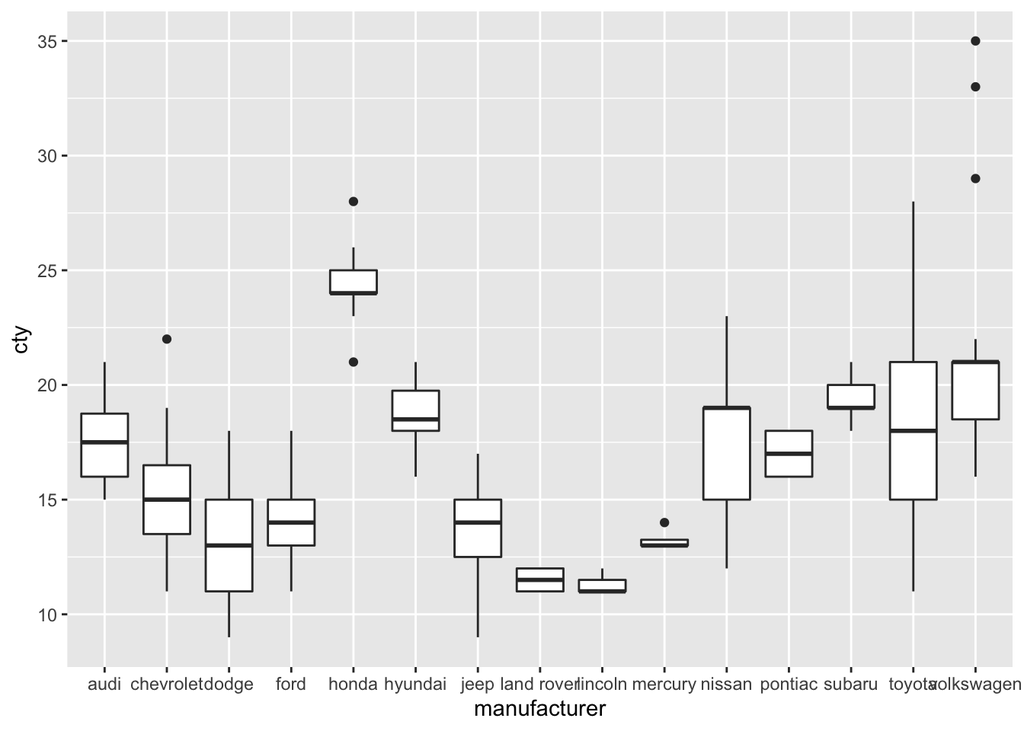

```r
ggplot(data = mpg,
       mapping = aes(x = manufacturer, y = cty)) +
  geom_boxplot()
```